# Prediction of Maximum Heart Rate Attained during Exercise

Zhi Rong Tan

December 08 2018

## Introduction

In this exercise, we are given a dataset of patients with certain heart and physical health conditions. The aim is to build a model for the response maxhr (maximum heart rate attained during exericse) based on the physical conditions of the participants. The focus of this exercise is on the careful treatment and application of linear statistical methods in data analysis.

## Data Processing

First, input the data into R. Observe that besides the binary categorical variables, we need to convert the other categorical variables with more than 2 levels into factor variables. The categorical variables with > 2 levels are: *chestpain*, *restecg*, *slope*, *extest*.

```r
heart = read.delim("heart.txt", sep="")
cor(heart)
```

```
##                age      sex chestpain   restbp      chol       fbs
## age        1.00000 -0.09754   0.10414  0.28495  0.208950  0.118530
## sex       -0.09754  1.00000   0.01008 -0.06446 -0.199915  0.047862
## chestpain  0.10414  0.01008   1.00000 -0.03608  0.072319 -0.039975
## restbp     0.28495 -0.06446  -0.03608  1.00000  0.130120  0.175340
## chol       0.20895 -0.19991   0.07232  0.13012  1.000000  0.009841
## fbs        0.11853  0.04786  -0.03997  0.17534  0.009841  1.000000
## restecg    0.14887  0.02165   0.06751  0.14656  0.171043  0.069564
## exang      0.09166  0.14620   0.38406  0.06476  0.061310  0.025665
## oldpeak    0.20381  0.10217   0.20228  0.18917  0.046564  0.005747
## slope      0.16177  0.03753   0.15205  0.11738 -0.004062  0.059894
## fluoro          NA       NA        NA       NA        NA        NA
## extest          NA       NA        NA       NA        NA        NA
## maxhr     -0.39381 -0.04866  -0.33442 -0.04535 -0.003432 -0.007854
##            restecg    exang   oldpeak     slope fluoro extest
## age        0.14887  0.09166  0.203805  0.161770     NA     NA
## sex        0.02165  0.14620  0.102173  0.037533     NA     NA
## chestpain  0.06751  0.38406  0.202277  0.152050     NA     NA
## restbp     0.14656  0.06476  0.189171  0.117382     NA     NA
## chol       0.17104  0.06131  0.046564 -0.004062     NA     NA
## fbs        0.06956  0.02567  0.005747  0.059894     NA     NA
## restecg    1.00000  0.08487  0.114133  0.133946     NA     NA
## exang      0.08487  1.00000  0.288223  0.257748     NA     NA
## oldpeak    0.11413  0.28822  1.000000  0.577537     NA     NA
## slope      0.13395  0.25775  0.577537  1.000000     NA     NA
## fluoro          NA       NA        NA        NA      1     NA
## extest          NA       NA        NA        NA     NA      1
## maxhr     -0.08339 -0.37810 -0.343085 -0.385601     NA     NA
##               maxhr
## age       -0.393806
## sex       -0.048663
## chestpain -0.334422
## restbp    -0.045351
## chol      -0.003432
## fbs       -0.007854
## restecg   -0.083389
## exang     -0.378103
## oldpeak   -0.343085
## slope     -0.385601
## fluoro           NA
## extest           NA
## maxhr      1.000000
```

```r
#Transform chestpain, restecg, slope, extest into categorical factor variables
heart$chestpain <- as.factor(heart$chestpain)
heart$restecg <- as.factor(heart$restecg)
heart$slope <- as.factor(heart$slope)
heart$extest <- as.factor(heart$extest)

summary(heart)
```

```
##       age            sex       chestpain     restbp         chol
##  Min.   :29.0   Min.   :0.00   1: 23     Min.   : 94   Min.   :126
##  1st Qu.:48.0   1st Qu.:0.00   2: 50     1st Qu.:120   1st Qu.:211
##  Median :56.0   Median :1.00   3: 86     Median :130   Median :241
##  Mean   :54.4   Mean   :0.68   4:144     Mean   :132   Mean   :247
##  3rd Qu.:61.0   3rd Qu.:1.00             3rd Qu.:140   3rd Qu.:275
##  Max.   :77.0   Max.   :1.00             Max.   :200   Max.   :564
##
##       fbs        restecg     exang          oldpeak     slope
##  Min.   :0.000   0:151   Min.   :0.000   Min.   :0.00   1:142
##  1st Qu.:0.000   1:  4   1st Qu.:0.000   1st Qu.:0.00   2:140
##  Median :0.000   2:148   Median :0.000   Median :0.80   3: 21
##  Mean   :0.148           Mean   :0.327   Mean   :1.04
##  3rd Qu.:0.000           3rd Qu.:1.000   3rd Qu.:1.60
##  Max.   :1.000           Max.   :1.000   Max.   :6.20
##
##      fluoro       extest        maxhr
##  Min.   :0.000   0   :166   Min.   : 71
##  1st Qu.:0.000   1   : 18   1st Qu.:134
##  Median :0.000   2   :117   Median :153
##  Mean   :0.672   NA's:  2   Mean   :150
##  3rd Qu.:1.000              3rd Qu.:166
##  Max.   :3.000              Max.   :202
##  NA's   :4
```

We have missing data in 2 variables, fluro and extest. Notice that there are 4 and 2 observaions missing respectively.

Although 6 observations in total is a small number, I want to consider the impact of other variables inside my model. Hence, instead of dropping the observations with missing values, I will impute the missing data. Imputing the mean is unsuitable given that one variable is categorical and one only takes in discrete values. Therefore, I will impute with the mode, which is 0 for both.

```r
#Explore the scatterplots of variables
#plot(fluoro~., data = heart)
#plot(extest~., data = heart)

#Note there is no significant relationship that makes imputing with regression an essential
#choice.

#Impute missing data with median (since extest is categorical, and fluro takes in discrete values from 0 to 3)
heart$extest[c(88, 267)] = 0
heart$fluoro[c(167, 303, 193, 288)] = 0
```

## Choosing Regression Variables

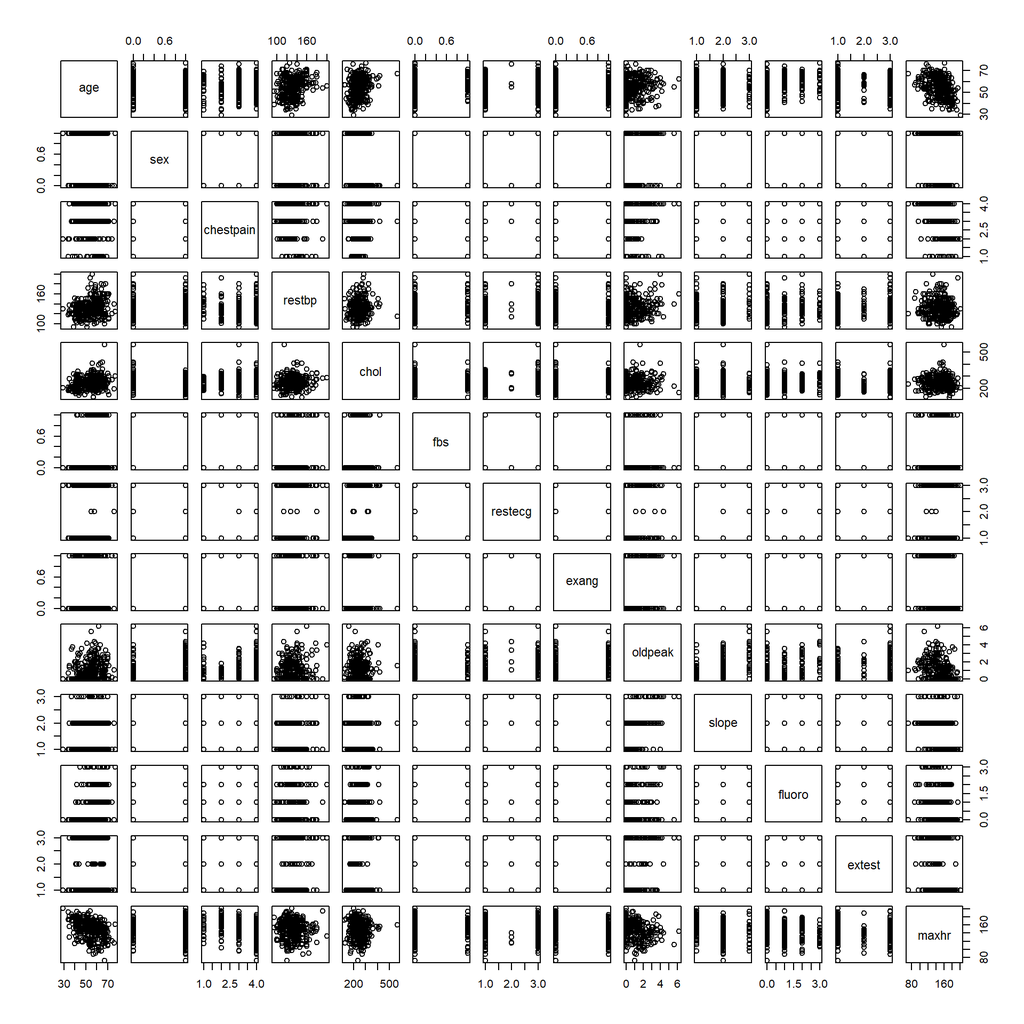

```r
#Let's analyze the relationship betwen the different variables remaining, on a plot.
plot(heart)
```

### Collinearity

Is there a need to worry for collinearity? For this, we look at the correlation matrix, and point out any correlation pairs that are > 0.70. Observe that the highest pairs are:

cor(exang, chestpain) = 0.384

cor(extest, exang) = 0.32

cor(slope, oldpeak) = 0.57

cor(age, fluoro) = 0.365

cor(sex, extest) = 0.3679

### Regression & Model Selection

Focus on the plot of maxhr with all other covariates.

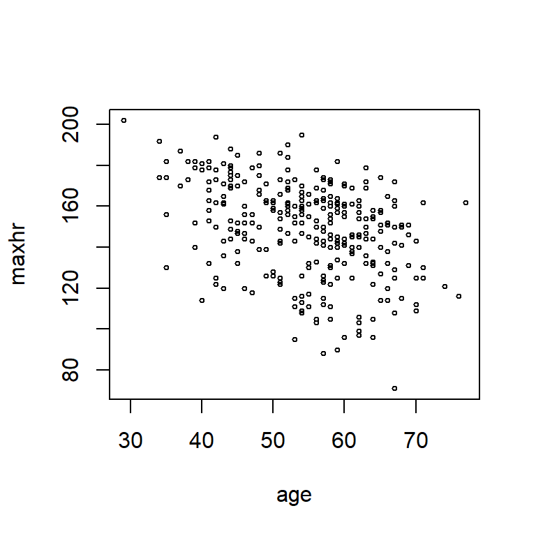

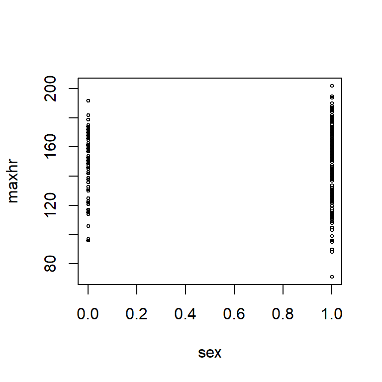

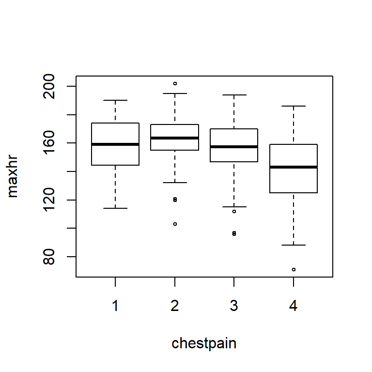

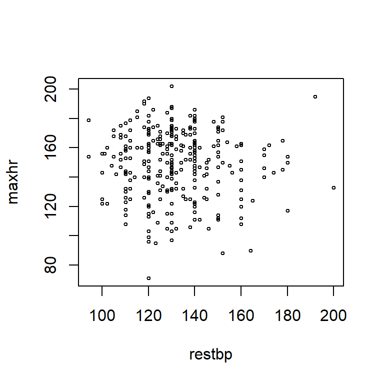

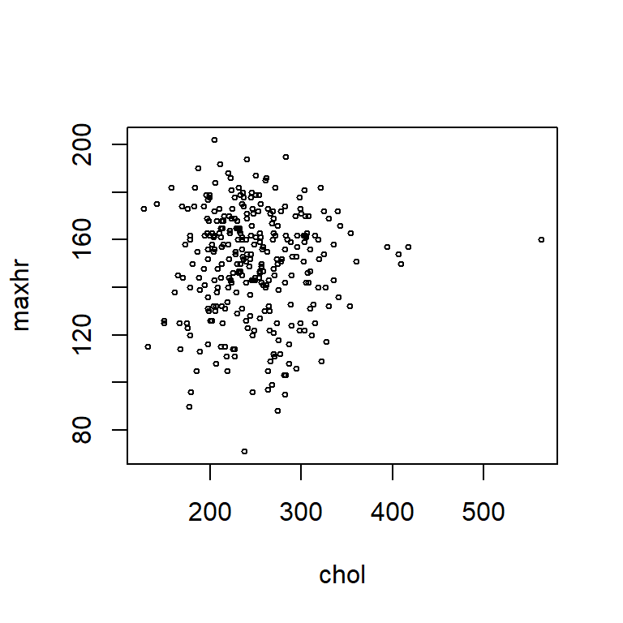

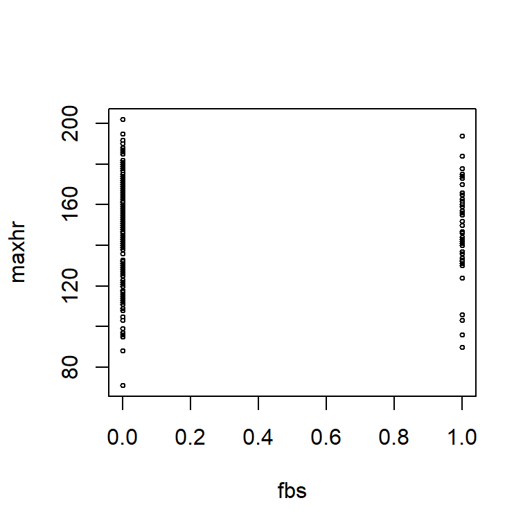

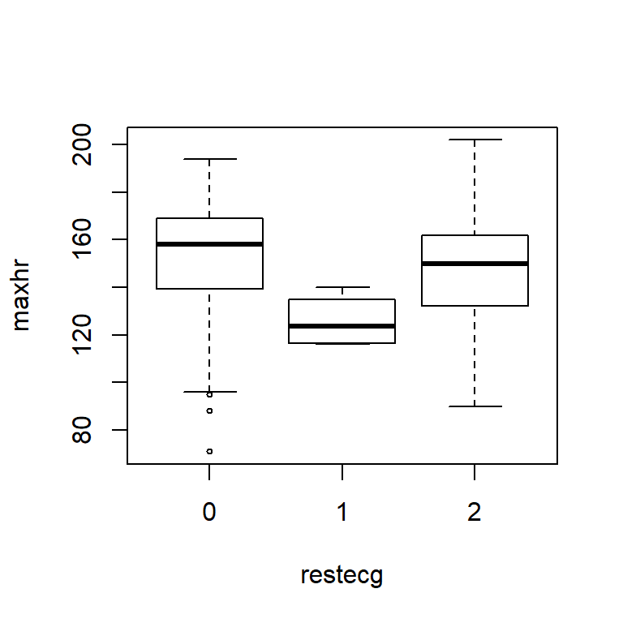

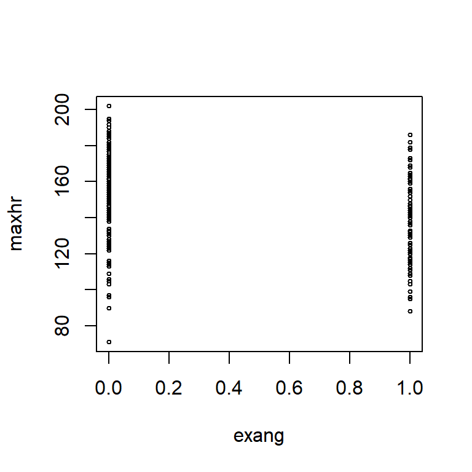

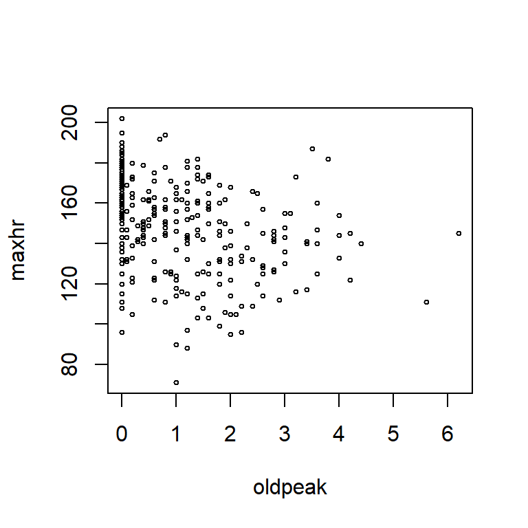

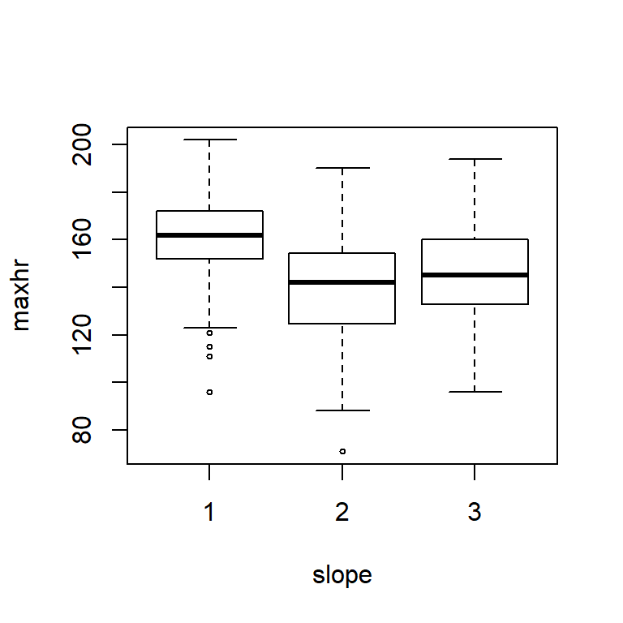

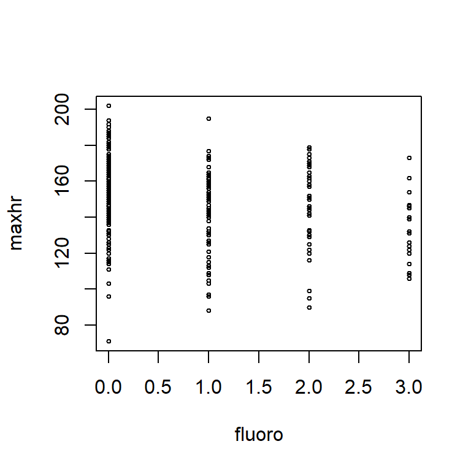

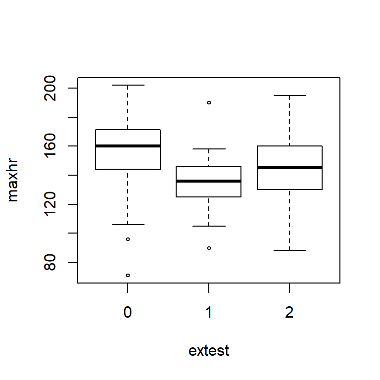

```r
plot(maxhr ~., data=heart, cex=0.5)
```

Other covariates, such as sex, restecg and restbp have a low correlation with maxhr. However, given the possibility of 2-way interaction of these covariates with other covariates in explaining maxhr, I will not discard these variables, and leave them in for now.

## Stepwise Backward Selection

With 12 covariates, I will perform backward stepwise selection, using both AIC and BIC as the criterion. In the initial model, I will consider up to 2-ways interaction.

At every point, we will find the AIC/BIC of all models if a particular covariate or interaction is dropped. Then, we will drop the covariate that gives the lowest AIC/BIC if it was dropped. The stopping criterion is only when the existing model has the lowest AIC/BIC compared to if we drop any other covariate and/or interaction. The difference between AIC and BIC is:
$$BIC = nlog(RSS/n) + plog(n)$$
$$AIC = nlog(RSS/n) + 2p$$
The difference between AIC and BIC is that in the penalization for a complex model with large p, the scaling constant is log(n) - the larger n is, the more larger covariates will be penalized, while for AIC, it is only the constant = 2. AIC will choose a larger model than BIC, but BIC penalizes model complexity more severely.

I will obtain the model based on both AIC and BIC as stopping criterion. For clarity, I have included the first and last steps of the Stepwise Selection procedure as comments, and removed the middle steps.

```r
model.one.max = lm(maxhr ~ (age+sex+chestpain+restbp+restecg+exang+oldpeak+
                       slope+fluoro+extest+fbs+chol)**2, data=heart)
stepwise = step(model.one.max, direction="backward", criterion="AIC", trace=0)

## Start:  AIC=1815
## maxhr ~ (age + sex + chestpain + restbp + restecg + exang + oldpeak +
##     slope + fluoro + extest + fbs + chol)^2
##
##                     Df Sum of Sq   RSS  AIC
## - chestpain:extest   6      1151 50487 1810
## - chestpain:exang    3       296 49633 1811
## - sex:chestpain      3       318 49655 1811
## - extest:fbs         2        10 49346 1811
## - chestpain:restecg  3       458 49795 1812
## - oldpeak:extest     2       155 49492 1812
## - chestpain:fbs      3       554 49891 1812
## - restecg:extest     2       273 49610 1813
## - chestpain:oldpeak  3       620 49957 1813
## - fluoro:chol        1         0 49337 1813
## - age:sex            1         0 49337 1813
## - restbp:oldpeak     1         1 49337 1813
## - oldpeak:fbs        1         1 49338 1813
## - age:fbs            1         4 49340 1813
## - age:exang          1         8 49344 1813
## - restbp:exang       1        12 49349 1813
## - fluoro:fbs         1        23 49360 1813
## - restbp:fbs         1        28 49364 1813
## - restbp:fluoro      1        37 49374 1813
## - restbp:restecg     1        64 49401 1813
## - age:restecg        1        66 49403 1813
## - restecg:fluoro     1        68 49404 1813
## - oldpeak:fluoro     1        70 49407 1814
## - fbs:chol           1       101 49437 1814
## - exang:fbs          1       117 49454 1814
## - age:restbp         1       119 49456 1814
## - restbp:extest      2       448 49785 1814
## - slope:fluoro       2       449 49786 1814
## - sex:oldpeak        1       124 49460 1814
## - age:fluoro         1       124 49460 1814
## - restecg:oldpeak    1       127 49464 1814
## - chestpain:fluoro   3       788 50125 1814
## - age:chol           1       139 49475 1814
## - oldpeak:chol       1       144 49480 1814
## - slope:extest       4      1148 50485 1814
## - restecg:exang      1       166 49502 1814
## - exang:oldpeak      1       192 49529 1814
## - extest:chol        2       552 49888 1814
## - restecg:chol       1       243 49579 1815
## - sex:chol           1       244 49581 1815
## - age:oldpeak        1       249 49586 1815
## - sex:restbp         1       324 49660 1815
## <none>                           49337 1815
## - exang:fluoro       1       384 49721 1815
## - exang:extest       2       752 50089 1816
## - age:chestpain      3      1177 50514 1816
## - slope:chol         2       860 50197 1816
## - sex:slope          2       861 50198 1816
## - sex:fbs            1       534 49870 1816
## - exang:chol         1       558 49895 1816
## - sex:fluoro         1       582 49918 1817
## - chestpain:restbp   3      1290 50627 1817
## - restecg:fbs        1       668 50004 1817
## - age:extest         2      1005 50342 1817
## - restbp:chol        1       686 50022 1817
## - fluoro:extest      2      1117 50454 1818
## - slope:fbs          2      1256 50592 1819
## - sex:extest         2      1295 50632 1819
## - sex:restecg        1      1001 50338 1819
## - age:slope          2      1476 50813 1820
## - oldpeak:slope      2      1480 50817 1820
## - chestpain:chol     3      2053 51390 1821
## - restbp:slope       2      1897 51233 1823
## - sex:exang          1      1796 51132 1824
## - restecg:slope      2      2628 51964 1827
## - exang:slope        2      2964 52300 1829
## - chestpain:slope    6      6480 55817 1840

#(Multiple steps in between)

## Step:  AIC=1730
## maxhr ~ age + sex + chestpain + restbp + restecg + exang + slope +
##     fluoro + extest + fbs + chol + age:chestpain + age:fluoro +
##     age:extest + sex:exang + sex:fluoro + sex:extest + sex:fbs +
##     chestpain:restbp + chestpain:slope + restbp:extest + restbp:chol +
##     restecg:slope + exang:slope + fluoro:extest
##
##                    Df Sum of Sq   RSS  AIC
## - exang:slope       2       819 67844 1730
## <none>                          67025 1730
## - restbp:chol       1       606 67631 1731
## - age:fluoro        1       753 67778 1731
## - age:extest        2      1239 68265 1731
## - age:chestpain     3      1814 68839 1732
## - sex:fluoro        1       913 67938 1732
## - fluoro:extest     2      1565 68590 1733
## - restbp:extest     2      1926 68952 1735
## - sex:fbs           1      1611 68636 1735
## - chestpain:restbp  3      2790 69815 1736
## - sex:extest        2      2374 69399 1736
## - restecg:slope     3      2889 69914 1737
## - sex:exang         1      3749 70774 1744
## - chestpain:slope   6      6717 73742 1747
##
## Step:  AIC=1730
## maxhr ~ age + sex + chestpain + restbp + restecg + exang + slope +
##     fluoro + extest + fbs + chol + age:chestpain + age:fluoro +
##     age:extest + sex:exang + sex:fluoro + sex:extest + sex:fbs +
##     chestpain:restbp + chestpain:slope + restbp:extest + restbp:chol +
##     restecg:slope + fluoro:extest
##
##                    Df Sum of Sq   RSS  AIC
## <none>                          67844 1730
## - restbp:chol       1       676 68520 1731
## - age:fluoro        1       699 68543 1731
## - age:chestpain     3      1803 69647 1732
## - age:extest        2      1358 69202 1732
## - fluoro:extest     2      1569 69414 1733
## - sex:fluoro        1      1218 69062 1733
## - restbp:extest     2      1943 69787 1734
## - sex:fbs           1      1754 69598 1735
## - sex:extest        2      2235 70079 1735
## - chestpain:restbp  3      2868 70712 1736
## - restecg:slope     3      3025 70869 1737
## - sex:exang         1      3399 71243 1742
## - chestpain:slope   6      6940 74785 1747

model.one.aic = lm(maxhr ~ age + sex + chestpain + restbp + restecg + exang + slope +
     fluoro + extest + fbs + chol + age:chestpain + age:fluoro +
     age:extest + sex:exang + sex:fluoro + sex:extest + sex:fbs +
     chestpain:restbp + chestpain:slope + restbp:extest + restbp:chol +
     restecg:slope + fluoro:extest, data = heart)
```

Next, let us proceed to BIC criterion.

```r
##BIC
step(model.one.max, direction="backward", criterion="BIC", k = log(303), trace=0)
```

```
##
## Call:
## lm(formula = maxhr ~ age + sex + exang + slope + sex:exang, data = heart)
##
## Coefficients:
## (Intercept)          age          sex        exang       slope2
##     202.376       -0.778        2.230       -1.020      -15.168
##      slope3    sex:exang
##     -10.584      -15.234
```

```r
## Start:  AIC=2320
## maxhr ~ (age + sex + chestpain + restbp + restecg + exang + oldpeak +
##     slope + fluoro + extest + fbs + chol)^2
##
##                     Df Sum of Sq   RSS  AIC
## - chestpain:extest   6      1151 50487 2293
## - slope:extest       4      1148 50485 2304
## - chestpain:exang    3       296 49633 2305
## - sex:chestpain      3       318 49655 2305
## - chestpain:restecg  3       458 49795 2306
## - chestpain:fbs      3       554 49891 2306
## - chestpain:oldpeak  3       620 49957 2307
## - chestpain:fluoro   3       788 50125 2308
## - extest:fbs         2        10 49346 2309
## - oldpeak:extest     2       155 49492 2310
## - age:chestpain      3      1177 50514 2310
## - restecg:extest     2       273 49610 2310
## - chestpain:restbp   3      1290 50627 2311
## - restbp:extest      2       448 49785 2311
## - slope:fluoro       2       449 49786 2311
## - extest:chol        2       552 49888 2312
## - exang:extest       2       752 50089 2313
## - slope:chol         2       860 50197 2314
## - sex:slope          2       861 50198 2314
## - fluoro:chol        1         0 49337 2314
## - age:sex            1         0 49337 2314
## - restbp:oldpeak     1         1 49337 2314
## - oldpeak:fbs        1         1 49338 2314
## - age:fbs            1         4 49340 2314
## - age:exang          1         8 49344 2314
## - restbp:exang       1        12 49349 2315
## - fluoro:fbs         1        23 49360 2315
## - restbp:fbs         1        28 49364 2315
## - restbp:fluoro      1        37 49374 2315
## - restbp:restecg     1        64 49401 2315
## - age:extest         2      1005 50342 2315
## - age:restecg        1        66 49403 2315
## - restecg:fluoro     1        68 49404 2315
## - oldpeak:fluoro     1        70 49407 2315
## - fbs:chol           1       101 49437 2315
## - exang:fbs          1       117 49454 2315
## - age:restbp         1       119 49456 2315
## - sex:oldpeak        1       124 49460 2315
## - age:fluoro         1       124 49460 2315
## - restecg:oldpeak    1       127 49464 2315
## - age:chol           1       139 49475 2315
## - oldpeak:chol       1       144 49480 2315
## - chestpain:chol     3      2053 51390 2315
## - restecg:exang      1       166 49502 2315
## - fluoro:extest      2      1117 50454 2316
## - exang:oldpeak      1       192 49529 2316
## - restecg:chol       1       243 49579 2316
## - sex:chol           1       244 49581 2316
## - age:oldpeak        1       249 49586 2316
## - slope:fbs          2      1256 50592 2316
## - sex:restbp         1       324 49660 2316
## - sex:extest         2      1295 50632 2317
## - exang:fluoro       1       384 49721 2317
## - age:slope          2      1476 50813 2318
## - oldpeak:slope      2      1480 50817 2318
## - sex:fbs            1       534 49870 2318
## - exang:chol         1       558 49895 2318
## - sex:fluoro         1       582 49918 2318
## - restecg:fbs        1       668 50004 2319
## - restbp:chol        1       686 50022 2319
## <none>                           49337 2320
## - restbp:slope       2      1897 51233 2320
## - sex:restecg        1      1001 50338 2321
## - chestpain:slope    6      6480 55817 2323
## - restecg:slope      2      2628 51964 2324
## - sex:exang          1      1796 51132 2325
## - exang:slope        2      2964 52300 2326

# (multiple steps in between)

## Step:  AIC=1795
## maxhr ~ age + sex + exang + slope + fbs + sex:exang
##
##             Df Sum of Sq    RSS  AIC
## - fbs        1       107  97400 1789
## <none>                    97293 1795
## - sex:exang  1      2770 100063 1797
## - slope      2     14558 111850 1825
## - age        1     14246 111539 1830
##
## Step:  AIC=1789
## maxhr ~ age + sex + exang + slope + sex:exang
##
##             Df Sum of Sq    RSS  AIC
## <none>                    97400 1789
## - sex:exang  1      2907 100308 1792
## - slope      2     14627 112028 1820
## - age        1     14165 111565 1825


model.one.bic = lm(maxhr ~ age + sex + exang + slope + sex:exang, data = heart)
summary(model.one.bic)
```

```
##
## Call:
## lm(formula = maxhr ~ age + sex + exang + slope + sex:exang, data = heart)
##
## Residuals:
##    Min     1Q Median     3Q    Max
## -66.33 -11.70   2.39  12.84  41.00
##
## Coefficients:
##             Estimate Std. Error t value      Pr(>|t|)
## (Intercept)  202.376      6.833   29.62       < 2e-16 ***
## age           -0.778      0.119   -6.56 0.00000000024 ***
## sex            2.230      2.658    0.84        0.4022
## exang         -1.020      4.458   -0.23        0.8192
## slope2       -15.168      2.284   -6.64 0.00000000015 ***
## slope3       -10.584      4.294   -2.46        0.0143 *
## sex:exang    -15.234      5.125   -2.97        0.0032 **
## ---
## Signif. codes:  0 '***' 0.001 '**' 0.01 '*' 0.05 '.' 0.1 ' ' 1
##
## Residual standard error: 18.1 on 296 degrees of freedom
## Multiple R-squared:  0.384,  Adjusted R-squared:  0.371
## F-statistic: 30.7 on 6 and 296 DF,  p-value: <2e-16
```

Obviously, the BIC chooses a much smaller model than AIC. Which is preferred? To decide, we will use the F-Test.

Recall that for the F-Test to investigate if a reduced model is sufficient, we require
$$F = \frac{(RSS_\omega - RSS_\lambda)/(p-q)}{RSS_\lambda/(n-p)} \sim F_{p-q,n-p}$$

Where $\omega$ is the reduced model, $\lambda$ is the full model, p is the number of variables in the full model, and q is the number of variables in the reduced model. Our null hypothesis is that the reduced model performs as well as the full model.

```r
#Compare between the 2 models
RSS.full = sum(model.one.aic$residuals^2)
RSS.red = sum(model.one.bic$residuals^2)
Fstat= (RSS.red-RSS.full)/(38) / (RSS.full/(258))
pval = 1 - pf(Fstat,38,258)
pval
```

```
## [1] 0.0000002058
```

Since p-value < 0.001, we reject the null hypothesis, and conclude that the full model from AIC is preferred.

When we check the summary for AIC final model, we observe that there are some variables with high p-value, meaning that the null hypothesis $\beta = 0$ cannot be rejected. However, for some categorical variables, only 1-2 factor levels are significant at the one-way or 2-way level. Yet, since the standard thing is to either keep the X:T term for all levels of T, or remove them all, we will determine using the F-test. In all scenarios, we will keep them.

### Cross Validation

To ensure that predictions will be accurate, let us perform a cross validation as well on the AIC and BIC model, and verify that AIC gives a better prediction. I will split the dataset into 3/4 (training) and 1/4 (validation). We will run the model on the training set to find the coefficients, but the variables selected will be the the selected variables by AIC and BIC stepwise, with different splitting into test and train set. Repeat the simulation for 100 times, and find the mean of the MSE for each model size.

```r
mse.function <- function (actual,pred) {
  sqrt(mean((actual - pred)^2))
}

aic.mse = rep(0, 100)
bic.mse = rep(0, 100)

for (i in 1:100) {
  set.seed(i*2)
  sample = sample(nrow(heart), size=(3/4)*nrow(heart), replace=F)
  train.set1 = heart[sample,]
  test.set1 = heart[-sample,]

  aic.test1 = lm(maxhr ~ age + sex + chestpain + restbp + restecg + exang + slope +
       fluoro + extest + fbs + chol + age:chestpain + age:fluoro +
       age:extest + sex:exang + sex:fluoro + sex:extest + sex:fbs +
      chestpain:restbp + chestpain:slope + restbp:extest + restbp:chol +
      restecg:slope + fluoro:extest, data = train.set1)
  aic.predict1 = predict(aic.test1, newdata=test.set1)
  aic.mse[i] = mse.function(test.set1$maxhr, aic.predict1)

  bic.test1 = lm(maxhr ~ age + sex + exang + slope + sex:exang, data = train.set1)
  bic.predict1 = predict(bic.test1, newdata=test.set1)
  bic.mse[i] = mse.function(test.set1$maxhr, bic.predict1)
}
mean(aic.mse)
```

```
## [1] 18.47
```

```r
mean(bic.mse)
```

```
## [1] 18.29
```

Interestingly, the BIC performs slightly better. However, this method is not particularly rigorous given that the difference in MSE is small. It is likely that the optimal model will be one that has a number of coefficients in between the optimal one chosen by AIC and BIC. Since it is easier to work downwards (remove variables from a larger model) than to work upwards (adding remaining p - q variables to a model with q variable), we will choose to work with the AIC-selected model instead of the BIC-selected model to find the final model that is a compromise of both.

## Reducing the Model

Under a predictive model, we should ensure the model do not get too overwhelming complex. Currently, our model contains 11/12 variables that the data presents, which may lead to concerns of overfitting and multiple testing. Hence, further reducing the AIC-selected model is essential.

Based on the coefficients, we will find several reduced models, and use the F-Test to determine if the reduced model is sufficient.

Because of model hierarchy, we face the following problems:

1. If we remove a one-way variable, we have to remove all its interaction terms too.
2. We either keep all levels of a factor variable, or remove all of them.

We explored a few models, but the more significant ones are presented below.

```r
summary(model.one.aic)
```

```
##
## Call:
## lm(formula = maxhr ~ age + sex + chestpain + restbp + restecg +
##     exang + slope + fluoro + extest + fbs + chol + age:chestpain +
##     age:fluoro + age:extest + sex:exang + sex:fluoro + sex:extest +
##     sex:fbs + chestpain:restbp + chestpain:slope + restbp:extest +
##     restbp:chol + restecg:slope + fluoro:extest, data = heart)
##
## Residuals:
##    Min     1Q Median     3Q    Max
## -53.19  -8.94   0.77  10.69  32.88
##
## Coefficients: (1 not defined because of singularities)
##                    Estimate Std. Error t value Pr(>|t|)
## (Intercept)       161.55614   50.30473    3.21  0.00149 **
## age                -1.59473    0.43531   -3.66  0.00030 ***
## sex                 2.05701    3.16790    0.65  0.51670
## chestpain2        -75.06274   37.06271   -2.03  0.04387 *
## chestpain3        -24.18139   33.67184   -0.72  0.47332
## chestpain4        -38.52799   32.81077   -1.17  0.24138
## restbp              0.57736    0.37941    1.52  0.12930
## restecg1           12.33078   23.32775    0.53  0.59755
## restecg2           -5.17962    2.93986   -1.76  0.07928 .
## exang               9.65017    4.88238    1.98  0.04916 *
## slope2             -4.32819    8.35773   -0.52  0.60499
## slope3            -15.86369   13.50234   -1.17  0.24112
## fluoro            -10.67597    8.72577   -1.22  0.22226
## extest1            56.53744   56.33127    1.00  0.31648
## extest2           -29.73572   21.55744   -1.38  0.16897
## fbs                -9.43636    5.71650   -1.65  0.10001
## chol                0.29813    0.15547    1.92  0.05627 .
## age:chestpain2      0.00217    0.50692    0.00  0.99659
## age:chestpain3      0.52724    0.47931    1.10  0.27236
## age:chestpain4      0.80009    0.45170    1.77  0.07770 .
## age:fluoro          0.22225    0.13630    1.63  0.10420
## age:extest1         1.58095    0.71485    2.21  0.02787 *
## age:extest2         0.23635    0.28709    0.82  0.41112
## sex:exang         -19.57385    5.44470   -3.60  0.00039 ***
## sex:fluoro         -6.04397    2.80810   -2.15  0.03230 *
## sex:extest1       -41.50252   21.08592   -1.97  0.05011 .
```

[output cut: 11 more lines]

```
## restbp:extest1     -0.76468    0.29187   -2.62  0.00932 **
## restbp:extest2      0.02071    0.12487    0.17  0.86839
## restbp:chol        -0.00189    0.00118   -1.60  0.11003
## restecg1:slope2   -24.28005   25.58023   -0.95  0.34342
## restecg2:slope2    12.58256    4.15796    3.03  0.00273 **
## restecg1:slope3          NA         NA      NA       NA
## restecg2:slope3    -1.96488    9.02641   -0.22  0.82785
## fluoro:extest1     -9.28189    6.05166   -1.53  0.12631
## fluoro:extest2      3.78064    2.48096    1.52  0.12877
## ---
## Signif. codes:  0 '***' 0.001 '**' 0.01 '*' 0.05 '.' 0.1 ' ' 1
##
## Residual standard error: 16.2 on 258 degrees of freedom
## Multiple R-squared:  0.571,  Adjusted R-squared:  0.497
## F-statistic: 7.79 on 44 and 258 DF,  p-value: <2e-16
```

```r
#Remove restecg
model.one.b = lm(maxhr ~ age + sex + chestpain + restbp +
    exang + slope + fluoro + extest + fbs + chol + age:chestpain +
    age:fluoro + age:extest + sex:exang + sex:fluoro + sex:extest +
    sex:fbs + chestpain:restbp + chestpain:slope + restbp:extest +
    restbp:chol + fluoro:extest, data = heart)

#F-Test
anova(model.one.aic, model.one.b)
```

```
## Analysis of Variance Table
##
## Model 1: maxhr ~ age + sex + chestpain + restbp + restecg + exang + slope +
##     fluoro + extest + fbs + chol + age:chestpain + age:fluoro +
##     age:extest + sex:exang + sex:fluoro + sex:extest + sex:fbs +
##     chestpain:restbp + chestpain:slope + restbp:extest + restbp:chol +
##     restecg:slope + fluoro:extest
## Model 2: maxhr ~ age + sex + chestpain + restbp + exang + slope + fluoro +
##     extest + fbs + chol + age:chestpain + age:fluoro + age:extest +
##     sex:exang + sex:fluoro + sex:extest + sex:fbs + chestpain:restbp +
##     chestpain:slope + restbp:extest + restbp:chol + fluoro:extest
##   Res.Df   RSS Df Sum of Sq    F Pr(>F)
## 1    258 67844
## 2    263 71236 -5     -3391 2.58  0.027 *
## ---
## Signif. codes:  0 '***' 0.001 '**' 0.01 '*' 0.05 '.' 0.1 ' ' 1
```

```r
#Cross Validation
full.mse = rep(0, 100)
red.mse = rep(0, 100)
for (i in 1:100) {
  set.seed(i)
  sample = sample(nrow(heart), size=(2/3)*nrow(heart), replace=F)
  train.set1 = heart[sample,]
  test.set1 = heart[-sample,]
  aic.test1 = lm(maxhr ~ age + sex + chestpain + restbp + restecg + exang + slope +
       fluoro + extest + fbs + chol + age:chestpain + age:fluoro +
       age:extest + sex:exang + sex:fluoro + sex:extest + sex:fbs +
      chestpain:restbp + chestpain:slope + restbp:extest + restbp:chol +
      restecg:slope + fluoro:extest, data = train.set1)
  aic.predict1 = predict(aic.test1, newdata=test.set1)
  full.mse[i] = mse.function(test.set1$maxhr, aic.predict1)

  red.test1 = lm(maxhr ~ age + sex + chestpain + restbp +
    exang + slope + fluoro + extest + fbs + chol + age:chestpain +
    age:fluoro + age:extest + sex:exang + sex:fluoro + sex:extest +
    sex:fbs + chestpain:restbp + chestpain:slope + restbp:extest +
    restbp:chol + fluoro:extest, data = train.set1)
  red.predict1 = predict(red.test1, newdata=test.set1)
  red.mse[i] = mse.function(test.set1$maxhr, red.predict1)
}
mean(full.mse)
```

```
## [1] 19.06
```

```r
mean(red.mse)
```

```
## [1] 18.85
```

Hence, since both F-test and cross validation agrees on the inference, we shall proceed with the smaller model. Let’s continue this way:

```r
model.one.b = lm(maxhr ~ age + sex + chestpain + restbp +
    exang + slope + fluoro + extest + fbs + chol + age:chestpain +
    age:fluoro + age:extest + sex:exang + sex:fluoro + sex:extest +
    sex:fbs + chestpain:restbp + chestpain:slope + restbp:extest +
    restbp:chol + fluoro:extest, data = heart)

#remove fluoro
model.one.ba = lm(maxhr ~ age + sex + chestpain + restbp +
    exang + slope + extest + fbs + chol + age:chestpain +
    age:extest + sex:exang + sex:extest +
    sex:fbs + chestpain:restbp + chestpain:slope + restbp:extest +
    restbp:chol, data = heart)

anova(model.one.b, model.one.ba)
```

```
## Analysis of Variance Table
##
## Model 1: maxhr ~ age + sex + chestpain + restbp + exang + slope + fluoro +
##     extest + fbs + chol + age:chestpain + age:fluoro + age:extest +
##     sex:exang + sex:fluoro + sex:extest + sex:fbs + chestpain:restbp +
##     chestpain:slope + restbp:extest + restbp:chol + fluoro:extest
## Model 2: maxhr ~ age + sex + chestpain + restbp + exang + slope + extest +
##     fbs + chol + age:chestpain + age:extest + sex:exang + sex:extest +
##     sex:fbs + chestpain:restbp + chestpain:slope + restbp:extest +
##     restbp:chol
##   Res.Df   RSS Df Sum of Sq    F Pr(>F)
## 1    263 71236
## 2    268 74938 -5     -3702 2.73   0.02 *
## ---
## Signif. codes:  0 '***' 0.001 '**' 0.01 '*' 0.05 '.' 0.1 ' ' 1
```

```r
full.mse = rep(0, 100)
red.mse = rep(0, 100)
for (i in 1:100) {
  set.seed(i*10)
  sample = sample(nrow(heart), size=(2/3)*nrow(heart), replace=F)
  train.set1 = heart[sample,]
  test.set1 = heart[-sample,]
  full.model1 = lm(maxhr ~ age + sex + chestpain + restbp +
    exang + slope + fluoro + extest + fbs + chol + age:chestpain +
    age:fluoro + age:extest + sex:exang + sex:fluoro + sex:extest +
    sex:fbs + chestpain:restbp + chestpain:slope + restbp:extest +
    restbp:chol + fluoro:extest, data = train.set1)
  full.predict1 = predict(full.model1, newdata=test.set1)
  full.mse[i] = mse.function(test.set1$maxhr, full.predict1)

  red.test1 = lm(maxhr ~ age + sex + chestpain + restbp +
    exang + slope + extest + fbs + chol + age:chestpain +
    age:extest + sex:exang + sex:extest +
    sex:fbs + chestpain:restbp + chestpain:slope + restbp:extest +
    restbp:chol, data = train.set1)
  red.predict1 = predict(red.test1, newdata=test.set1)
  red.mse[i] = mse.function(test.set1$maxhr, red.predict1)
}
mean(full.mse)
```

```
## [1] 19
```

```r
mean(red.mse)
```

```
## [1] 18.85
```

At 1% significance level, since the F-test for a reduced model removing fluoro terms has p-value of 0.02 > 0.01, and the cross validation gives a (slightly) better performance than the full model, let us remove fluoro from our model.

### Next Steps

We attempt to simplify the models with the same step as above. In our F-test, we will take 1% significance level, and will attempt to remove the variables to find a reduced model that works as well (i.e. p-value in f-Test > 0.01)

```r
model.one.ba = lm(maxhr ~ age + sex + chestpain + restbp + exang + slope + extest +
                    fbs + chol + age:chestpain + age:extest + sex:exang + sex:extest +
    sex:fbs + chestpain:restbp + chestpain:slope + restbp:extest +
    restbp:chol, data = heart)

#Next, consider removing fbs
model.one.ba01 = lm(maxhr ~ age + sex + chestpain + restbp + exang + slope + extest +
                    chol + age:chestpain + age:extest + sex:exang + sex:extest +
    chestpain:restbp + chestpain:slope + restbp:extest +restbp:chol, data = heart)
anova(model.one.ba, model.one.ba01)
```

```
## Analysis of Variance Table
##
## Model 1: maxhr ~ age + sex + chestpain + restbp + exang + slope + extest +
##     fbs + chol + age:chestpain + age:extest + sex:exang + sex:extest +
##     sex:fbs + chestpain:restbp + chestpain:slope + restbp:extest +
##     restbp:chol
## Model 2: maxhr ~ age + sex + chestpain + restbp + exang + slope + extest +
##     chol + age:chestpain + age:extest + sex:exang + sex:extest +
##     chestpain:restbp + chestpain:slope + restbp:extest + restbp:chol
##   Res.Df   RSS Df Sum of Sq    F Pr(>F)
## 1    268 74938
## 2    270 76631 -2     -1693 3.03   0.05 .
## ---
## Signif. codes:  0 '***' 0.001 '**' 0.01 '*' 0.05 '.' 0.1 ' ' 1
```

```r
#REMOVE fbs
```

```r
#Next, consider removing extest
model.one.01 = lm(maxhr ~ age + sex + chestpain + restbp + exang + slope +
                    chol + age:chestpain + sex:exang +
    chestpain:restbp + chestpain:slope +
    restbp:chol, data = heart)
anova(model.one.ba01, model.one.01)
```

```
## Analysis of Variance Table
##
## Model 1: maxhr ~ age + sex + chestpain + restbp + exang + slope + extest +
##     chol + age:chestpain + age:extest + sex:exang + sex:extest +
##     chestpain:restbp + chestpain:slope + restbp:extest + restbp:chol
## Model 2: maxhr ~ age + sex + chestpain + restbp + exang + slope + chol +
##     age:chestpain + sex:exang + chestpain:restbp + chestpain:slope +
##     restbp:chol
##   Res.Df   RSS Df Sum of Sq    F Pr(>F)
## 1    270 76631
## 2    278 80463 -8     -3832 1.69    0.1
```

```r
#Since F-test p-value is 0.1 > 0.01, remove extest.


#Consider removing restbp
model.one.02 = lm(maxhr ~ age + sex + chestpain + exang + slope +
                    chol + age:chestpain + sex:exang +
    chestpain:slope, data = heart)
anova(model.one.02, model.one.01)
```

```
## Analysis of Variance Table
##
## Model 1: maxhr ~ age + sex + chestpain + exang + slope + chol + age:chestpain +
##     sex:exang + chestpain:slope
## Model 2: maxhr ~ age + sex + chestpain + restbp + exang + slope + chol +
##     age:chestpain + sex:exang + chestpain:restbp + chestpain:slope +
##     restbp:chol
##   Res.Df   RSS Df Sum of Sq    F Pr(>F)
## 1    283 83569
## 2    278 80463  5      3106 2.15   0.06 .
## ---
## Signif. codes:  0 '***' 0.001 '**' 0.01 '*' 0.05 '.' 0.1 ' ' 1
```

```r
#Since F-test p-value is 0.06, remove restbp
```

After this, we attempted to remove other variables, but the p-value of the F-tests are all very small, implying that the model should not be reduced.

```r
anova(model.one.bic, model.one.02)
```

```
## Analysis of Variance Table
##
## Model 1: maxhr ~ age + sex + exang + slope + sex:exang
## Model 2: maxhr ~ age + sex + chestpain + exang + slope + chol + age:chestpain +
##     sex:exang + chestpain:slope
##   Res.Df   RSS Df Sum of Sq   F   Pr(>F)
## 1    296 97400
## 2    283 83569 13     13831 3.6 0.000029 ***
## ---
## Signif. codes:  0 '***' 0.001 '**' 0.01 '*' 0.05 '.' 0.1 ' ' 1
```

```r
full.mse = rep(0, 100)
red.mse = rep(0, 100)
for (i in 1:100) {
  set.seed(i*10)
  sample = sample(nrow(heart), size=(2/3)*nrow(heart), replace=F)
  train.set1 = heart[sample,]
  test.set1 = heart[-sample,]
  full.model1 = lm(maxhr ~ age + sex + chestpain + exang + slope + chol +
                    age:chestpain + sex:exang +
    chestpain:slope, data = train.set1)
  full.predict1 = predict(full.model1, newdata=test.set1)
  full.mse[i] = mse.function(test.set1$maxhr, full.predict1)

  red.test1 = lm(maxhr ~ age + sex + exang + slope + sex:exang, data = train.set1)
  red.predict1 = predict(red.test1, newdata=test.set1)
  red.mse[i] = mse.function(test.set1$maxhr, red.predict1)
}
mean(full.mse)
```

```
## [1] 18.16
```

```r
mean(red.mse)
```

```
## [1] 18.43
```

Since p-value = 0.000029 < 0.1, then it is indeed a better fit. Moreover, the cross validation leads to the bigger model having a better prediction. I ran the simulation for a few times, and the MSE for the bigger model is always smaller.

Perhaps we can remove some interaction terms.

```r
#Remove chestpain:age
model.two = lm(maxhr ~ age + sex + chestpain + exang + slope + chol +
                    sex:exang + chestpain:slope, data = heart)
anova(model.two, model.one.02)
```

```
## Analysis of Variance Table
##
## Model 1: maxhr ~ age + sex + chestpain + exang + slope + chol + sex:exang +
##     chestpain:slope
## Model 2: maxhr ~ age + sex + chestpain + exang + slope + chol + age:chestpain +
##     sex:exang + chestpain:slope
##   Res.Df   RSS Df Sum of Sq    F Pr(>F)
## 1    286 85047
## 2    283 83569  3      1478 1.67   0.17
```

```r
#p-value for f-test = 0.17 > 0.01. Hence, remove age:chestpain.

model.two.a = lm(maxhr ~ age + sex + chestpain + exang + slope + chol +
                    sex:exang, data = heart)
anova(model.two, model.two.a)
```

```
## Analysis of Variance Table
##
## Model 1: maxhr ~ age + sex + chestpain + exang + slope + chol + sex:exang +
##     chestpain:slope
## Model 2: maxhr ~ age + sex + chestpain + exang + slope + chol + sex:exang
##   Res.Df   RSS Df Sum of Sq  F  Pr(>F)
## 1    286 85047
## 2    292 92191 -6     -7145  4 0.00072 ***
## ---
## Signif. codes:  0 '***' 0.001 '**' 0.01 '*' 0.05 '.' 0.1 ' ' 1
```

```r
#p-value for f-test is small. Do not remove interact term for chestpain:slope.

summary(model.two)
```

```
##
## Call:
## lm(formula = maxhr ~ age + sex + chestpain + exang + slope +
##     chol + sex:exang + chestpain:slope, data = heart)
##
## Residuals:
##    Min     1Q Median     3Q    Max
## -56.85 -11.12   2.04  10.76  34.98
##
## Coefficients:
##                   Estimate Std. Error t value      Pr(>|t|)
## (Intercept)       191.5723     9.3921   20.40       < 2e-16 ***
## age                -0.7848     0.1172   -6.70 0.00000000011 ***
## sex                 1.5049     2.6356    0.57        0.5685
## chestpain2          3.2678     6.4641    0.51        0.6136
## chestpain3         -1.9373     6.2896   -0.31        0.7583
## chestpain4          1.2325     6.2793    0.20        0.8445
## exang               3.2643     4.4775    0.73        0.4666
## slope2              2.8763     7.8312    0.37        0.7137
## slope3            -17.1757    11.5752   -1.48        0.1390
## chol                0.0416     0.0201    2.07        0.0395 *
## sex:exang         -14.8661     4.9945   -2.98        0.0032 **
## chestpain2:slope2 -15.6212     9.7817   -1.60        0.1114
## chestpain3:slope2  -8.7499     8.7654   -1.00        0.3190
## chestpain4:slope2 -26.6153     8.4619   -3.15        0.0018 **
## chestpain2:slope3  20.3799    17.0472    1.20        0.2329
## chestpain3:slope3  21.6337    14.2396    1.52        0.1298
## chestpain4:slope3  -2.0975    12.9778   -0.16        0.8717
## ---
## Signif. codes:  0 '***' 0.001 '**' 0.01 '*' 0.05 '.' 0.1 ' ' 1
##
## Residual standard error: 17.2 on 286 degrees of freedom
## Multiple R-squared:  0.462,  Adjusted R-squared:  0.432
## F-statistic: 15.3 on 16 and 286 DF,  p-value: <2e-16
```

```r
anova(model.two)
```

```
## Analysis of Variance Table
##
## Response: maxhr
##                  Df Sum Sq Mean Sq F value         Pr(>F)
## age               1  24507   24507   82.41        < 2e-16 ***
## sex               1   1210    1210    4.07        0.04464 *
## chestpain         3  16463    5488   18.45 0.000000000057 ***
## exang             1   7184    7184   24.16 0.000001497609 ***
## slope             2  12401    6201   20.85 0.000000003519 ***
## chol              1   1237    1237    4.16        0.04233 *
## sex:exang         1   2833    2833    9.53        0.00222 **
## chestpain:slope   6   7145    1191    4.00        0.00072 ***
## Residuals       286  85047     297
## ---
## Signif. codes:  0 '***' 0.001 '**' 0.01 '*' 0.05 '.' 0.1 ' ' 1
```

The anova analysis of model.two verifies that this is a good model. Note that in the sequential adding of covariates, the p-value shown above are all < 0.05.

Hence, we will now proceed with the model that is slightly bigger than the BIC optimal model:
$$maxhr \approx age + sex + chestpain + exang + slope + chol + sex*exang + chestpain*slope$$
With 6 covariates and 2 interaction terms.

### 3-Way Interaction

Since the model is already complex enough, we will not include 3-way interaction to improve the fit since they are not significantly required.

## Diagnostics

First we will check 2 model assumptions - constant variance, and normality.

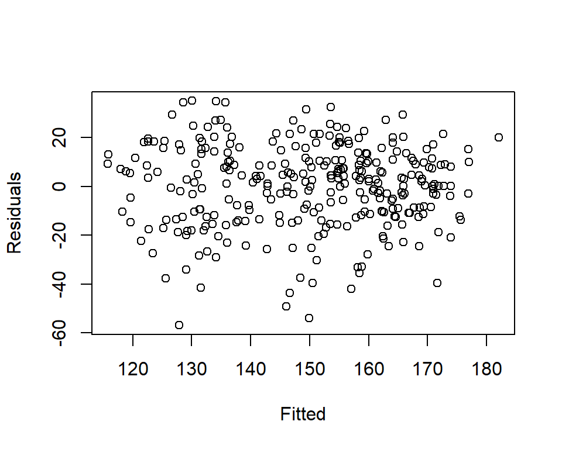

```r
#Check for constant variance
plot(model.two$fitted.values, model.two$residuals, xlab="Fitted", ylab="Residuals")
```

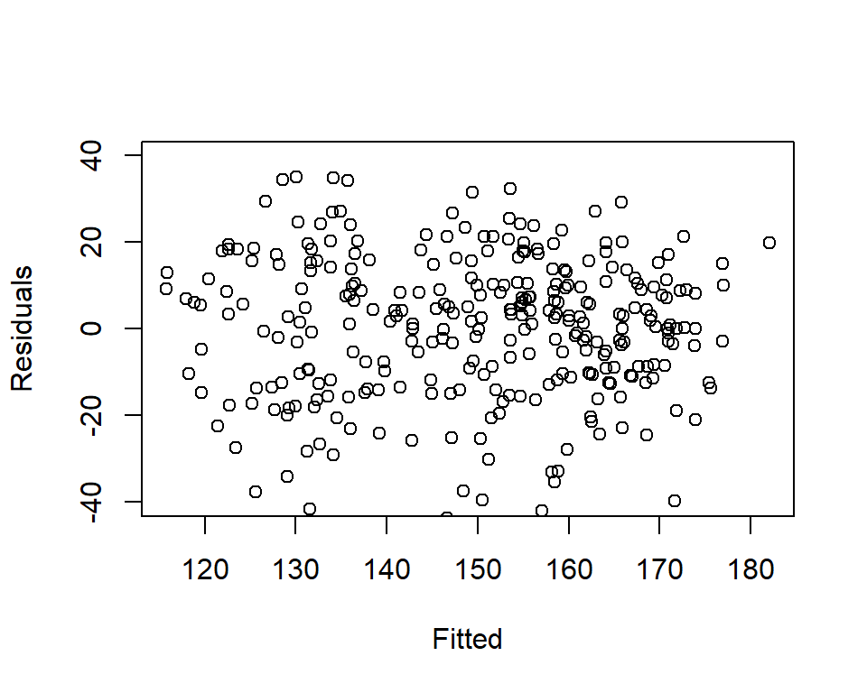

```r
#Remove the observations below -40.
plot(model.two$fitted.values, model.two$residuals, xlab="Fitted", ylab="Residuals",
     ylim=c(-40,40))
```

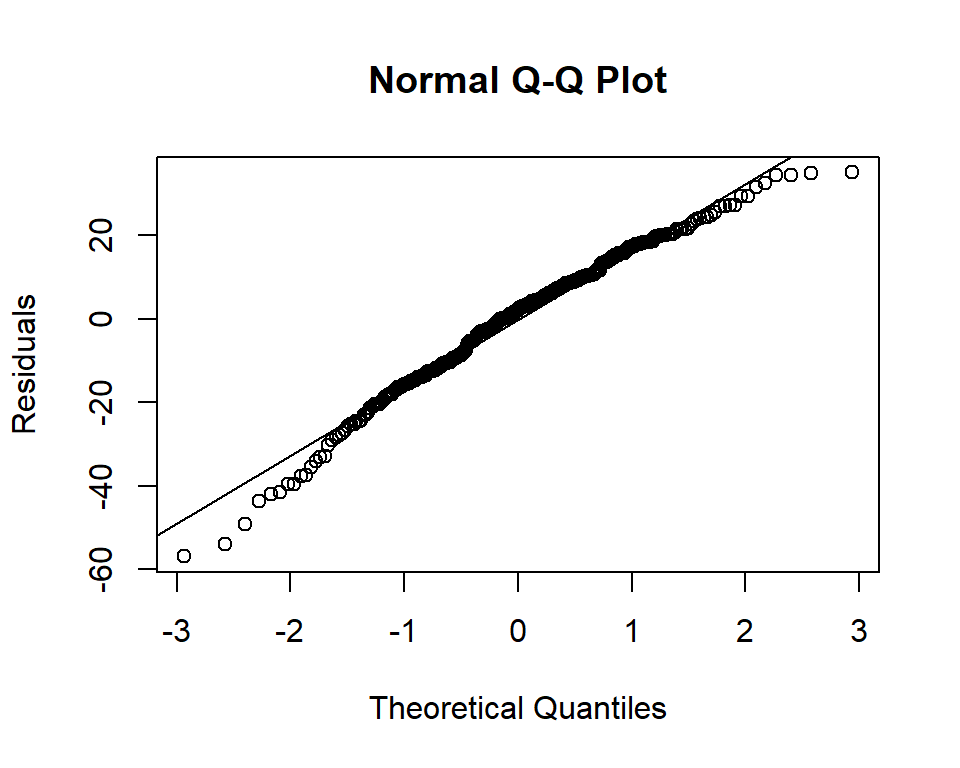

```r
#Check for normality in errors
qqnorm(residuals(model.two), ylab="Residuals")
qqline(residuals(model.two))
```

Some observations have extremely (negatively small) residuals, but otherwise, observe that the variance is rather constant, and well distributed. Note that there seem to be 2 clusters, splitting at fitted value = 140, but since the cluster is not very distinguished, we will just keep in view for now.

Notice that the residuals are fairly normal, at least from the -1.5 to 2nd quantile. It may be slightly heavy-tailed.

Let us also plot the residuals against the continuous covariate, to ensure there is constant variance, and no need to transform any variables.

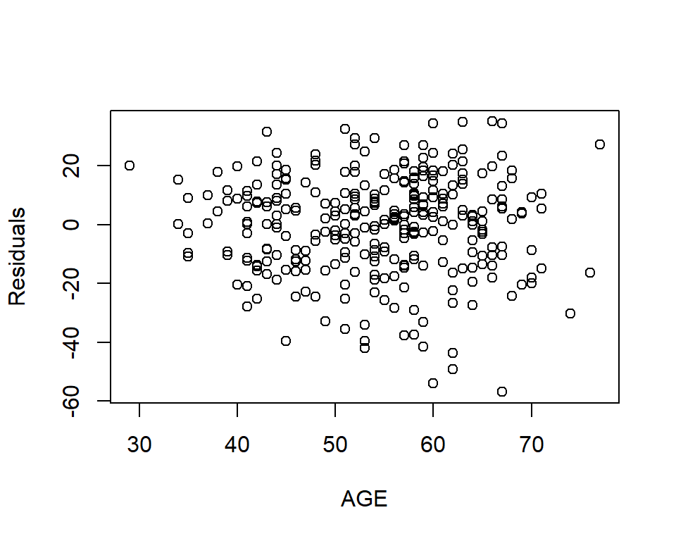

```r
plot(heart$age, model.two$residuals, xlab="AGE", ylab="Residuals")
```

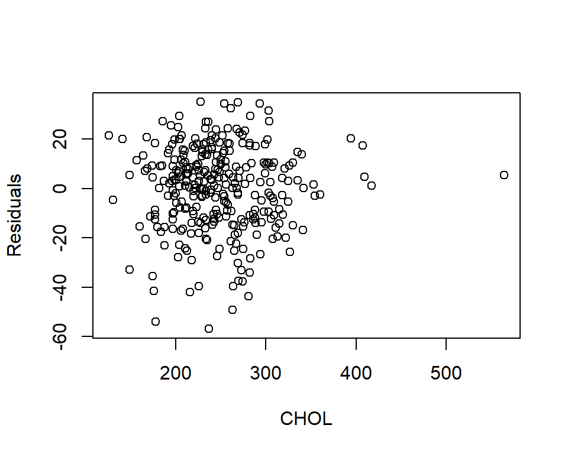

```r
plot(heart$chol, model.two$residuals, xlab="CHOL", ylab="Residuals")
```

Notice that there may be a small likelihood of increasing variance in errors as age increases. For Chol, it seems to be normally distributed, but have a few leverage points and points with large negative residuals.

To resolve this, we will complete additional diagnostics test, to indentify any leverage, outliers, and influential points.

### Leverage Points

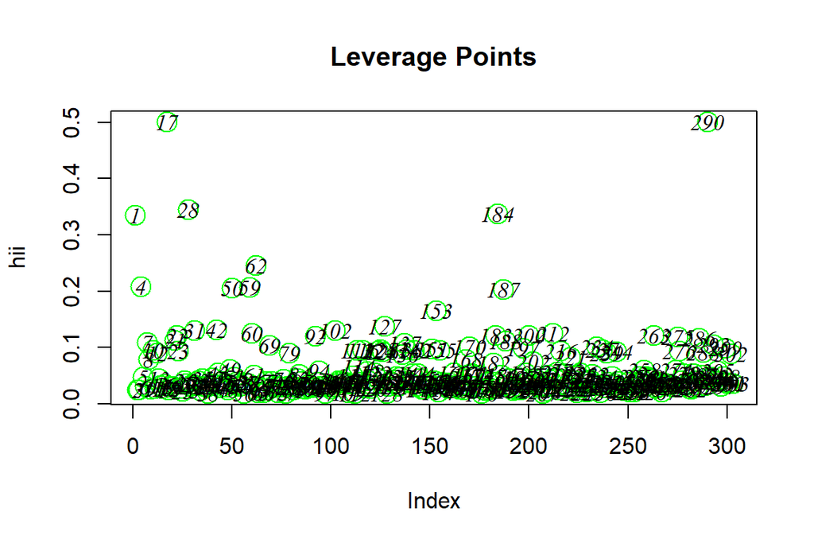

```r
hii <- influence(model.two)$hat
plot(hii, cex=2, col="green", main="Leverage Points")
with(heart, text(hii, font=8))
```

The leverage points are 17, 290, 1, 28, 184.

### Outliers

Define $X_{(i)}$ as having removed the i-th observation, and $y_{(i)}$ as the corresponding response value. Recall that
$$t_i = \frac{y_i-\hat{y_{(i)}}}{\hat{\sigma^2_{(i)}(1+x_i^T(X_{(i)}^TX_{(i)})^{-1}x_i)^{1/2}}} \sim t_{n-p-1}$$
Here, n = 303, n-p-1 = 286. Based on the Bonferroni Correction, we reject the null hypothesis if the critical value > 3.818

```r
qt(0.05/(303*2), 286)
```

```
## [1] -3.818
```

```r
jack <- abs(rstudent(model.two))

#There is no observations with values > 3.8. Hence, we will find the top 5 observations.
jack[jack>2.5]
```

```
##   115   138   245   246
## 2.939 2.691 3.247 3.409
```

### Influential Points

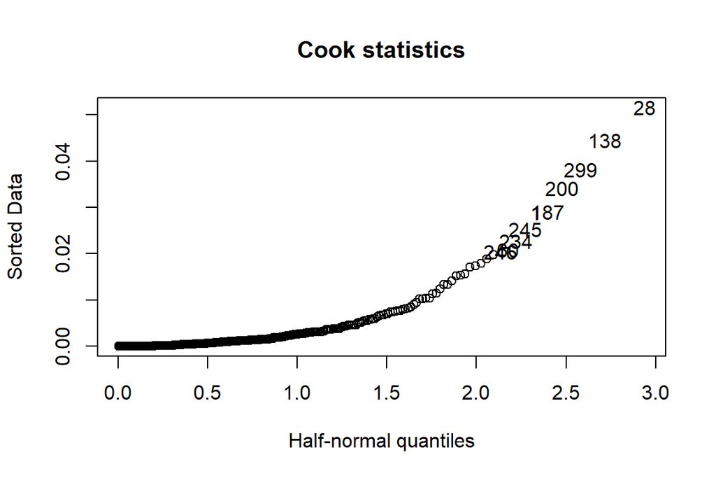

```r
halfnorm(cooks.distance(model.two), 10,
         main="Cook statistics")
```

Influential points = 28, 138, 299, 200, 187, 1, 245, 234

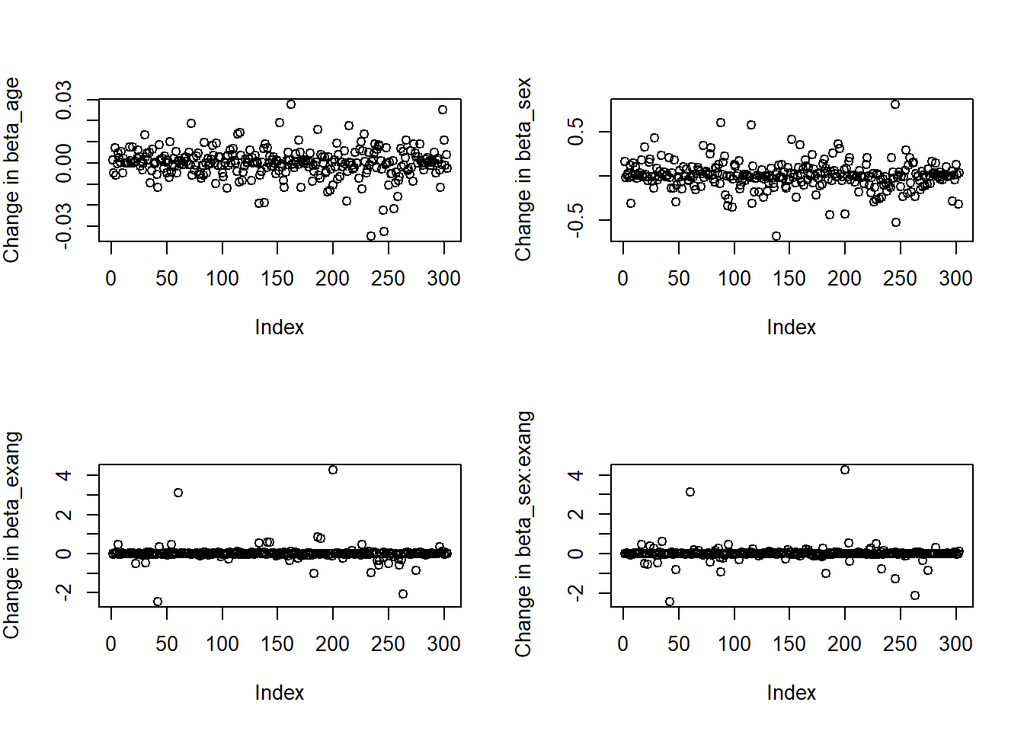

```r
influence1 <- influence(model.two)
par(mfrow=c(2,2))
plot(influence1$coef[,2],
     ylab=expression(paste("Change in beta_age")))
with(heart, text(heart$age, font=8))
plot(influence1$coef[,3],
     ylab=expression(paste("Change in beta_sex")))
plot(influence1$coef[,4],
     ylab=expression(paste("Change in beta_exang")))
plot(influence1$coef[,5],
     ylab=expression(paste("Change in beta_sex:exang")))
```

Based on the results, let us remove the significant influential points, and regress the model on the new dataset again.

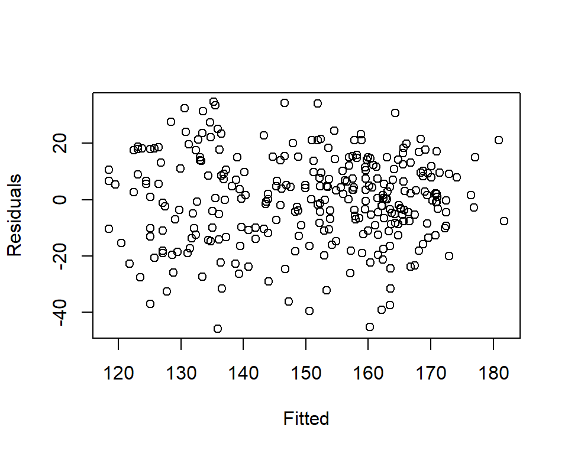

```r
remove = c(115, 245, 246, 200, 60, 28, 138, 299, 187)
heart.new = heart[-remove,]

model.two.a = lm(maxhr ~ age + sex + chestpain + exang + slope +
                    sex:exang + chestpain:slope, data = heart.new)


#Check the model assumptions again
#Check for constant variance
plot(model.two.a$fitted.values, model.two.a$residuals, xlab="Fitted", ylab="Residuals")
```

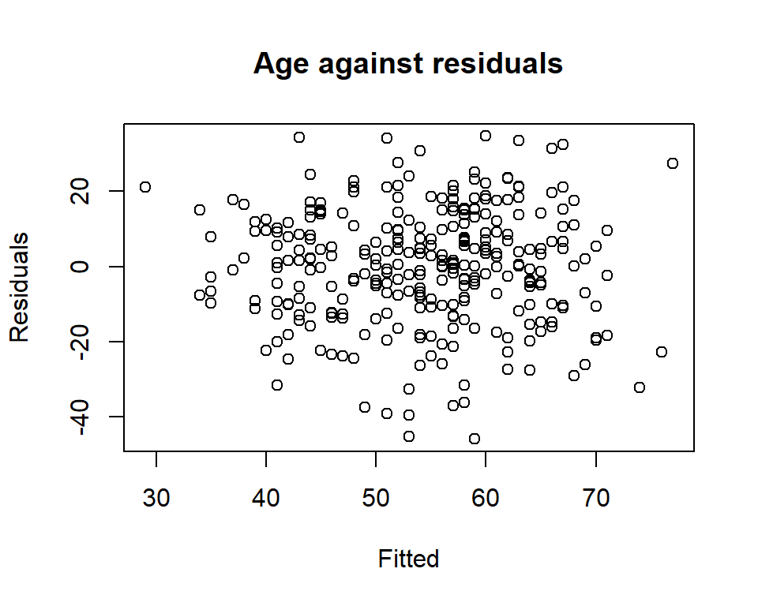

```r
plot(heart.new$age, model.two.a$residuals, xlab="Fitted", ylab="Residuals",
     main="Age against residuals")
```

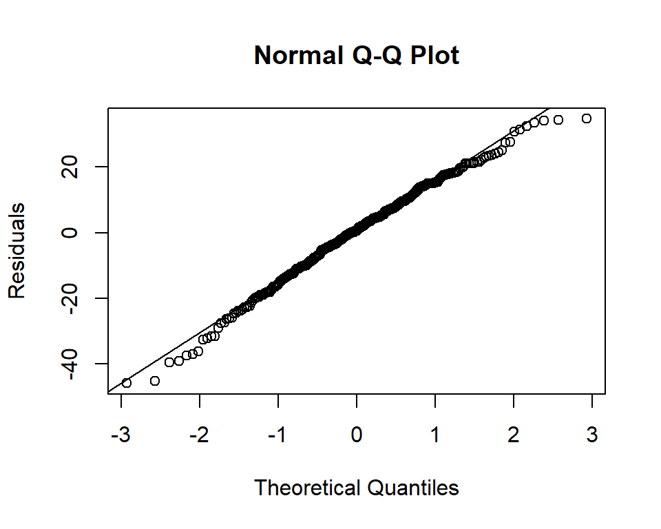

```r
#Check for normality in errors
qqnorm(residuals(model.two.a), ylab="Residuals")
qqline(residuals(model.two.a))
```

Indeed, observe that improvements were made to both the normality QQ plot and the fitted-variance plot, becoming closer to the assumptions.

### Huber Regression

Another method for robust regression is to use the Huber regression method. Here, instead of minimizing the square of the differences between predicted and actual value, we will minimize the absolute value of the differences once the difference is above a certain value.

```r
model.three = rlm(maxhr ~ age + sex + chestpain + exang + slope + chol +
                    sex:exang + chestpain:slope, data=heart, maxit=100)
summary(model.three)
```

```
##
## Call: rlm(formula = maxhr ~ age + sex + chestpain + exang + slope +
##     chol + sex:exang + chestpain:slope, data = heart, maxit = 100)
## Residuals:
##     Min      1Q  Median      3Q     Max
## -58.013 -11.812   0.888  10.056  35.366
##
## Coefficients:
##                   Value   Std. Error t value
## (Intercept)       193.656   9.248     20.941
## age                -0.748   0.115     -6.484
## sex                 1.259   2.595      0.485
## chestpain2          1.380   6.365      0.217
## chestpain3         -2.005   6.193     -0.324
## chestpain4         -0.227   6.183     -0.037
## exang               1.800   4.409      0.408
## slope2              2.211   7.711      0.287
## slope3            -19.536  11.397     -1.714
## chol                0.034   0.020      1.716
## sex:exang         -13.413   4.918     -2.727
## chestpain2:slope2 -12.590   9.631     -1.307
## chestpain3:slope2  -9.199   8.631     -1.066
## chestpain4:slope2 -25.814   8.332     -3.098
## chestpain2:slope3  22.675  16.785      1.351
## chestpain3:slope3  22.503  14.021      1.605
## chestpain4:slope3   0.724  12.779      0.057
##
## Residual standard error: 16.3 on 286 degrees of freedom
```

Observe that there are some similarities with the values. The coefficients for the Huber regression takes a mix of the values of coefficients from both the original model and the updated model after removal of influential and outlier points.

## Ridge Regression

Since the core of the question is about predicting maxhr based on the given covariates, we should recognize there exists a variance-bias tradeoff, given that we do NOT know that range of covariates that we will be predicting against. Hence, we should utilize Ridge regression to introduce some bias, in order to reduce the variance of future predictions.

The function we are minimizing is
$$argmin ||Y - X\hat{\beta}||^2 + \lambda ||\hat{\beta}||^2$$

First, we need to tune our hyperparameter, $\lambda$. We will do so by Leave-One-Out Cross Validation, and choose the $\lambda$ that gives us the lowest risk score.

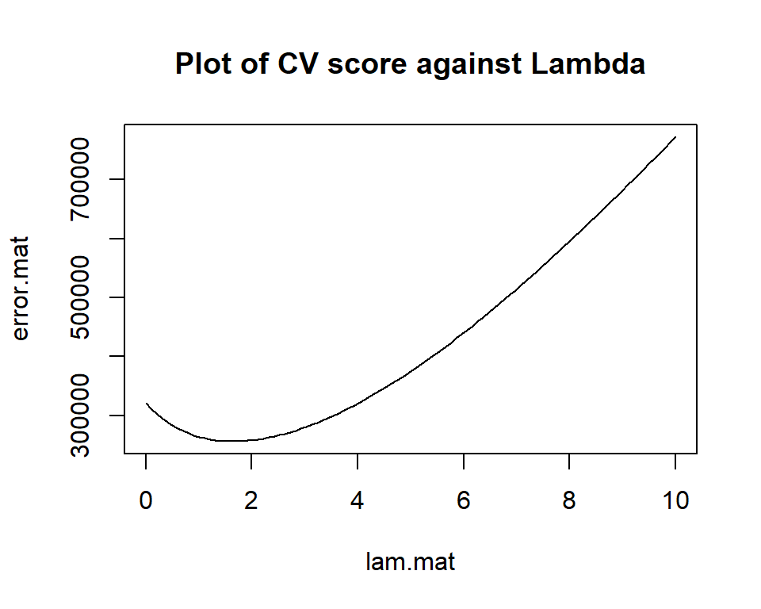

```r
#Set up data matrix for Ridge Regression prediction
heart2 = matrix(0, ncol=17, nrow=303)
heart2[, 1] = 1
heart2[, 2] = heart$age
heart2[, 3] = heart$sex
for (i in 1:303) {
  if (heart$chestpain[i] == 2) {heart2[i, 4] = 1}
  if (heart$chestpain[i] == 3) {heart2[i, 5] = 1}
  if (heart$chestpain[i] == 4) {heart2[i, 6] = 1}
}
heart2[, 7] = heart$exang
for (i in 1:303) {
  if (heart$slope[i] == 2) {heart2[i, 8] = 1}
  if (heart$slope[i] == 3) {heart2[i, 9] = 1}
}
heart2[, 10] = heart2[, 3] * heart2[, 7]
heart2[, 11] = heart2[, 4] * heart2[, 8]
heart2[, 12] = heart2[, 5] * heart2[, 8]
heart2[, 13] = heart2[, 6] * heart2[, 8]
heart2[, 14] = heart2[, 4] * heart2[, 9]
heart2[, 15] = heart2[, 5] * heart2[, 9]
heart2[, 16] = heart2[, 6] * heart2[, 9]
heart2[, 17] = heart$chol


lam.mat = seq(0,10, length=100)
error.mat = rep(0, 100)
for (i in 1:length(lam.mat)) {
  error.sum = 0
  for (j in 1:303) {
    model = lm.ridge(heart$maxhr[-j] ~ heart$age[-j]+heart$sex[-j]+heart$chestpain[-j]+
                       heart$exang[-j]+heart$slope[-j] + (heart$sex[-j])*(heart$exang[-j]) +
                       heart$chestpain[-j]*heart$slope[-j] + heart$chol[-j], lambda = lam.mat[i])
    y.pred = heart2[j,] %*% coef(model)
diff.2 = (y.pred - heart[j,13])^2
error.sum = error.sum + diff.2
}
error = error.sum/303
error.mat[i] = error
}
plot(lam.mat, error.mat, type="l", main="Plot of CV score against Lambda")
```

```r
index = which.min(error.mat)
opt.lam = lam.mat[index]
opt.lam
```

```
## [1] 1.616
```

Finally, given that we have chosen the bandwidth parameter, let’s run the regression to find out about our final model.

```r
model.opt.ridge = lm.ridge(heart$maxhr ~ heart$age+heart$sex+heart$chestpain+
                       heart$exang+heart$slope + (heart$sex)*(heart$exang) +
                       heart$chestpain*heart$slope + heart$chol, lambda = opt.lam)
coef(model.opt.ridge)
```

```
##                                                   heart$age
##                     192.23640                      -0.78018
##                     heart$sex              heart$chestpain2
##                       1.48132                       2.42844
##              heart$chestpain3              heart$chestpain4
##                      -2.75953                       0.23507
##                   heart$exang                  heart$slope2
##                       2.91395                       1.08740
##                  heart$slope3                    heart$chol
##                     -17.23256                       0.04139
##         heart$sex:heart$exang heart$chestpain2:heart$slope2
##                     -14.49699                     -13.76648
## heart$chestpain3:heart$slope2 heart$chestpain4:heart$slope2
##                      -6.96422                     -24.52978
## heart$chestpain2:heart$slope3 heart$chestpain3:heart$slope3
##                      20.34176                      21.66221
## heart$chestpain4:heart$slope3
##                      -1.87316
```

## Analysis

From above, we have obtained 3 models, *model.two* (from model selection process), *model.three* (robust regression process), and *model.opt.ridge* (from ridge regression process).

If we are suppose to predict a new observation that has covariates not in the range of the heart data, then we should use the model obtained from Ridge Regression, given that it introduces some biases to lower overall variance, ensuring that the model will neither overfit our existing data, nor underfit new data.

Otherwise, we should consider the model obtained from Huber regression. Note that the Huber model behaves like LS regression for small residuals, but if the residuals is large, it behaves like LAD regression. This is because when we perform diagnostics for the selected model, we noticed some problems, and detected some influential points and outliers. Hence, since Huber is a robust regression method, it prevents final results from being overwhelmingly affected by outliers.

```r
summary(model.two)
```

```
##
## Call:
## lm(formula = maxhr ~ age + sex + chestpain + exang + slope +
##     chol + sex:exang + chestpain:slope, data = heart)
##
## Residuals:
##    Min     1Q Median     3Q    Max
## -56.85 -11.12   2.04  10.76  34.98
##
## Coefficients:
##                   Estimate Std. Error t value      Pr(>|t|)
## (Intercept)       191.5723     9.3921   20.40       < 2e-16 ***
## age                -0.7848     0.1172   -6.70 0.00000000011 ***
## sex                 1.5049     2.6356    0.57        0.5685
## chestpain2          3.2678     6.4641    0.51        0.6136
## chestpain3         -1.9373     6.2896   -0.31        0.7583
## chestpain4          1.2325     6.2793    0.20        0.8445
## exang               3.2643     4.4775    0.73        0.4666
## slope2              2.8763     7.8312    0.37        0.7137
## slope3            -17.1757    11.5752   -1.48        0.1390
## chol                0.0416     0.0201    2.07        0.0395 *
## sex:exang         -14.8661     4.9945   -2.98        0.0032 **
## chestpain2:slope2 -15.6212     9.7817   -1.60        0.1114
## chestpain3:slope2  -8.7499     8.7654   -1.00        0.3190
## chestpain4:slope2 -26.6153     8.4619   -3.15        0.0018 **
## chestpain2:slope3  20.3799    17.0472    1.20        0.2329
## chestpain3:slope3  21.6337    14.2396    1.52        0.1298
## chestpain4:slope3  -2.0975    12.9778   -0.16        0.8717
## ---
## Signif. codes:  0 '***' 0.001 '**' 0.01 '*' 0.05 '.' 0.1 ' ' 1
##
## Residual standard error: 17.2 on 286 degrees of freedom
## Multiple R-squared:  0.462,  Adjusted R-squared:  0.432
## F-statistic: 15.3 on 16 and 286 DF,  p-value: <2e-16
```

```r
summary(model.three)
```

```
##
## Call: rlm(formula = maxhr ~ age + sex + chestpain + exang + slope +
##     chol + sex:exang + chestpain:slope, data = heart, maxit = 100)
## Residuals:
##     Min      1Q  Median      3Q     Max
## -58.013 -11.812   0.888  10.056  35.366
##
## Coefficients:
##                   Value   Std. Error t value
## (Intercept)       193.656   9.248     20.941
## age                -0.748   0.115     -6.484
## sex                 1.259   2.595      0.485
## chestpain2          1.380   6.365      0.217
## chestpain3         -2.005   6.193     -0.324
## chestpain4         -0.227   6.183     -0.037
## exang               1.800   4.409      0.408
## slope2              2.211   7.711      0.287
## slope3            -19.536  11.397     -1.714
## chol                0.034   0.020      1.716
## sex:exang         -13.413   4.918     -2.727
## chestpain2:slope2 -12.590   9.631     -1.307
## chestpain3:slope2  -9.199   8.631     -1.066
## chestpain4:slope2 -25.814   8.332     -3.098
## chestpain2:slope3  22.675  16.785      1.351
## chestpain3:slope3  22.503  14.021      1.605
## chestpain4:slope3   0.724  12.779      0.057
##
## Residual standard error: 16.3 on 286 degrees of freedom
```

```r
coef(model.opt.ridge)
```

```
##                                                   heart$age
##                     192.23640                      -0.78018
##                     heart$sex              heart$chestpain2
##                       1.48132                       2.42844
##              heart$chestpain3              heart$chestpain4
##                      -2.75953                       0.23507
##                   heart$exang                  heart$slope2
##                       2.91395                       1.08740
##                  heart$slope3                    heart$chol
##                     -17.23256                       0.04139
##         heart$sex:heart$exang heart$chestpain2:heart$slope2
##                     -14.49699                     -13.76648
## heart$chestpain3:heart$slope2 heart$chestpain4:heart$slope2
##                      -6.96422                     -24.52978
## heart$chestpain2:heart$slope3 heart$chestpain3:heart$slope3
##                      20.34176                      21.66221
## heart$chestpain4:heart$slope3
##                      -1.87316
```

#### Level of Significance

Since all 3 models are roughly similar in the sign of each coefficient, and only differs in magnitude, I will proceed with interpreting the main model, *model.two*, on which the latter 2 models are built.

First, notice that only 5 coefficients have p-values of < 0.10 in the t-test. Then, why are other covariates included? This is because the 5 are:

1. Intercept
2. age
3. chol
4. sex:exang
5. chestpain(4):slope(2)

Since it is unnatural to include interaction terms if the variables are not included in the model, we included them all, since accordingly to the F-test, the bigger model will be preferred even if the one-way covariates are not significant. Moreover, if we want to include a level of the categorical variable, we have to include all the levels.

#### Interpretation

- The intercept is 191.57. This implies that if a person is just born, female, and has no issues in other categories, then the maxhr = 191.57. This is on the high side, but fair considering that age 0 is outside the age range of data - hence, some extrapolation and distance from the means cause this error.
- Next, coefficient for age is negative. Hence, the older a person is, the lower his/her maxhr will be, controlled for other variables. This makes logical sense.
- A male is expected to have a maxhr of 1.5049 more compared to a female, other factors controlled. This is insignificantly small, but is understandable since the p-value is large too. More likely sex only plays a big role in interaction.
- When controlled for other factors, a person with the largest maxhr is likely to be one with chestpain2, followed by chestpain4, then chestpain1, finally chestpain3 has the smallest maxhr.
- If a female person has exercise-induced angina, she is likely to have a higher maxhr of 3.2643 than another female, when other variables are controlled.
- If the person is male, then this difference changes by (3.2643 - 14.8661) - interestingly, when controlled for other factors besides exang and sex, exang has an opposite effect on males, it gives them a lower maxhr.
- Similarly, a person with slope2’s ECG change will have a slightly higher maxhr than slope1. Yet, slope3 will have a large decrease in maxhr than slope1.
- There are also interactions between chestpain and slope. If a person has slope2 AND chestpain, then his/her maxhr will decrease rather significantly. On the reverse, if a person has Slope3 AND chestpain (but only of type 2 and 3), then his maxhr will increase by almost 20. This accounts for why slope3 has a negative (but large in magnitude) coefficient; it will be cancelled out if a persona has chestpain 2 or 3. Hence, slope2 and slope3 interacts with chestpain rather differently, in opposite direction in fact.
- When controlled for other variables, an increase in chol by 1 leads to an increase in Maxhr by 0.0416.

#### Conclusion:

In our final model, we include 6 variables (age, sex, chestpain, exang, slope, chol) and 2 interactions (sex:exang, chestpain:slope). To account for outliers and the usage of the model (predictive nature), we also utilize Robust Regression (Huber) and Ridge Regression to introduce variants of the model.